[figure not shown]

# Analysis on the Olympics dataset

## Datasets

The core datasets used for this task were taken from [Kaggle](https://www.kaggle.com/heesoo37/120-years-of-olympic-history-athletes-and-results).

This is a well-analysed dataset with over 100 kernels pinned against it on Kaggle. To enrich my analysis, and make it original, I also scraped some other datasets:

> - I used a dataset of capital city Latitude & Longitudes from [Techslides](http://techslides.com/list-of-countries-and-capitals).
> - I manually created a new dataset of olympic host city Altitudes, Latitudes & Longitudes from [mapcoordinates](http://www.mapcoordinates.net/en).

## Running environment

I used a Jupyter Notebook (Python 3) to narrate my analysis.

## Download dependencies

ON FIRST RUN: execute the code below to download the geopy dependency.

```python
import sys
!{sys.executable} -m pip install geopy
```

## Load packages

The following packages were used for the analysis:

```python
#load packages
import pandas as pd
import numpy as np
import matplotlib.pyplot as  plt
import seaborn as sns
import unittest
#import difflib - not used
from geopy.distance import vincenty, geodesic

%pylab inline
%matplotlib inline
```

# Contents

My analysis is laid out as follows:

#### Stage 1: Initial look at the data

> Link to initial look at the data

#### Stage 2: Feature engineering

> Link to feature engineering section of the report

#### Stage 3: Research questions

Following a review of the data available and a brainstorming session, I decided to focus my efforts on the following areas:

> Summary statistics to explore how athletes have changed over the years

> Analysis of some interesting countries

> Is there a correlation between Distance Travelled to the Games and performance and has that changed since 1980?

#### Stage 4: Conclusions

> Conclusions and further research options

> ...any finally - what about the Jamaican bobsleigh team?

#### Contact details

> Contact details

## Initial look at the data

```python
#Loading athlete data
data = pd.read_csv('athlete_events.csv', index_col = 'ID')
data.head(10)
```

| ID | Name | Sex | Age | Height | Weight | Team | NOC | Games | Year | Season | City | Sport | Event | Medal |
| --- | --- | --- | --- | --- | --- | --- | --- | --- | --- | --- | --- | --- | --- | --- |
| 1 | A Dijiang | M | 24.0 | 180.0 | 80.0 | China | CHN | 1992 Summer | 1992 | Summer | Barcelona | Basketball | Basketball Men's Basketball | NaN |
| 2 | A Lamusi | M | 23.0 | 170.0 | 60.0 | China | CHN | 2012 Summer | 2012 | Summer | London | Judo | Judo Men's Extra-Lightweight | NaN |
| 3 | Gunnar Nielsen Aaby | M | 24.0 | NaN | NaN | Denmark | DEN | 1920 Summer | 1920 | Summer | Antwerpen | Football | Football Men's Football | NaN |
| 4 | Edgar Lindenau Aabye | M | 34.0 | NaN | NaN | Denmark/Sweden | DEN | 1900 Summer | 1900 | Summer | Paris | Tug-Of-War | Tug-Of-War Men's Tug-Of-War | Gold |
| 5 | Christine Jacoba Aaftink | F | 21.0 | 185.0 | 82.0 | Netherlands | NED | 1988 Winter | 1988 | Winter | Calgary | Speed Skating | Speed Skating Women's 500 metres | NaN |
| 5 | Christine Jacoba Aaftink | F | 21.0 | 185.0 | 82.0 | Netherlands | NED | 1988 Winter | 1988 | Winter | Calgary | Speed Skating | Speed Skating Women's 1,000 metres | NaN |
| 5 | Christine Jacoba Aaftink | F | 25.0 | 185.0 | 82.0 | Netherlands | NED | 1992 Winter | 1992 | Winter | Albertville | Speed Skating | Speed Skating Women's 500 metres | NaN |
| 5 | Christine Jacoba Aaftink | F | 25.0 | 185.0 | 82.0 | Netherlands | NED | 1992 Winter | 1992 | Winter | Albertville | Speed Skating | Speed Skating Women's 1,000 metres | NaN |
| 5 | Christine Jacoba Aaftink | F | 27.0 | 185.0 | 82.0 | Netherlands | NED | 1994 Winter | 1994 | Winter | Lillehammer | Speed Skating | Speed Skating Women's 500 metres | NaN |
| 5 | Christine Jacoba Aaftink | F | 27.0 | 185.0 | 82.0 | Netherlands | NED | 1994 Winter | 1994 | Winter | Lillehammer | Speed Skating | Speed Skating Women's 1,000 metres | NaN |

A couple of early observations, upon loading the data:

> - NA in the Medal column have been converted to NaN, needs correcting.
> - Team variable combines > 1 Country, which is interesting, but unhelpful, will look to merge with the NOC table to clean.
> - It looks like Games is just a concat of Year + Season, should remove, once checked.
> - there's some NaN's in the Height & Weight Column , will need to be cleaned if using these columns.
> - There's some interesting sports from way-back-when - including Tug-Of-War, maybe these would be interesting to look at!

### Fill NaN values in Medal column with 'None'

```python
#Replace NA in Medal column with None
data['Medal'] = data['Medal'].fillna("None")
data['Medal'].head()
```

```
ID
1    None
2    None
3    None
4    Gold
5    None
Name: Medal, dtype: object
```

### Loading the NOC dataset

I want to use the NOC dataset to get a better representation of where an athlete is from over 'Team' variable.

```python
#Loading in the NOC dataset
NOC = pd.read_csv('noc_regions.csv')
```

### String replacement: replacing incorrect/ shorterned country names in the NOC dataset

Later on in the analysis, I do fuzzy matching of Country Names to join with the Capital Cities metadata dataset. After doing this, I changed this part of the script to include the fuzzy matches that the algorithm highlighted. i.e. before it is merged in the main data frame.

```python
NOC['region'].replace(['US', 'USA', 'UK', 'Saint Kitts', 'Trinidad', 'Boliva', 'Virgin Islands, US', 'Curacao'],
                      ['United States', 'United States', 'United Kingdom', 'Saint Kitts and Nevis',
                       'Trinidad and Tobago', 'Bolivia', 'US Virgin Islands', 'Cura̤ao'],
                      inplace = True)
```

```python
data = pd.merge(data, NOC, left_on='NOC', right_on='NOC')
```

```python
#before discarding, check to see if Games is in Year + Season for all values, then discard.
if (data['Games'].equals(data['Year'].map(str) + " " + data['Season'])):
    data = data.drop(['notes', 'Games'], axis=1)
else:
    data = data.drop(['notes'], axis=1)
```

```python
data.sample()
```

|  | Name | Sex | Age | Height | Weight | Team | NOC | Year | Season | City | Sport | Event | Medal | region |
| --- | --- | --- | --- | --- | --- | --- | --- | --- | --- | --- | --- | --- | --- | --- |
| 258795 | Miroslav Cerar | M | 20.0 | 172.0 | 73.0 | Yugoslavia | YUG | 1960 | Summer | Roma | Gymnastics | Gymnastics Men's Parallel Bars | None | Serbia |

We can see above that Games == Year + Season for all values, and so is removed from the dataset.

### Review of null values in the dataset

```python
# assign a list of (ColumnName, NullCount) tuples to null_list using list comprehension
null_list = [(col, data[col].isnull().sum()) for col in data.columns]
print(null_list)
```

```
[('Name', 0), ('Sex', 0), ('Age', 9462), ('Height', 60083), ('Weight', 62785), ('Team', 0), ('NOC', 0), ('Year', 0), ('Season', 0), ('City', 0), ('Sport', 0), ('Event', 0), ('Medal', 0), ('region', 21)]
```

```python
df_nulls = pd.DataFrame(null_list)
df_nulls
```

|  | 0 | 1 |
| --- | --- | --- |
| 0 | Name | 0 |
| 1 | Sex | 0 |
| 2 | Age | 9462 |
| 3 | Height | 60083 |
| 4 | Weight | 62785 |
| 5 | Team | 0 |
| 6 | NOC | 0 |
| 7 | Year | 0 |
| 8 | Season | 0 |
| 9 | City | 0 |
| 10 | Sport | 0 |
| 11 | Event | 0 |
| 12 | Medal | 0 |
| 13 | region | 21 |

We can see that only the Age, Height, Weight & the newly created region columns contain null values. My instinct tells me that this is because they didn't record age/height/weight measurements before a certain date. We'll have to investigate the region nulls a bit further.

### Investigating the region nulls

We can see below that these are being caused by the Refugee Olympic Athletes Team, Unknowns and Tuvalu. I will remove these rows from the dataset.

```python
#find out which points haven't merged properly
missing_region_datapoints = data[data.region.isnull()]
print(len(missing_region_datapoints))
missing_region_datapoints.sample(5)
```

```
21
```

|  | Name | Sex | Age | Height | Weight | Team | NOC | Year | Season | City | Sport | Event | Medal | region |
| --- | --- | --- | --- | --- | --- | --- | --- | --- | --- | --- | --- | --- | --- | --- |
| 270681 | A. Laffen | M | NaN | NaN | NaN | Unknown | UNK | 1912 | Summer | Stockholm | Art Competitions | Art Competitions Mixed Architecture | None | NaN |
| 264747 | Yusra Mardini | F | 18.0 | 157.0 | 53.0 | Refugee Olympic Athletes | ROT | 2016 | Summer | Rio de Janeiro | Swimming | Swimming Women's 100 metres Butterfly | None | NaN |
| 270682 | Logona Esau | M | 21.0 | 163.0 | 69.0 | Tuvalu | TUV | 2008 | Summer | Beijing | Weightlifting | Weightlifting Men's Lightweight | None | NaN |
| 264746 | Yusra Mardini | F | 18.0 | 157.0 | 53.0 | Refugee Olympic Athletes | ROT | 2016 | Summer | Rio de Janeiro | Swimming | Swimming Women's 100 metres Freestyle | None | NaN |
| 264743 | Yonas Kinde | M | 36.0 | 172.0 | 57.0 | Refugee Olympic Athletes | ROT | 2016 | Summer | Rio de Janeiro | Athletics | Athletics Men's Marathon | None | NaN |

```python
# remove rows with NaN in the region column, using prints to check
print(len(data))
data = data[pd.notnull(data['region'])]
print(len(data))
```

```
270767
270746
```

# Feature engineering

I chose to use external datasets to enrich the analyse and build novel feature sets. This section shows how I went about it. In this section most of the code is wrapped around unit tests to ensure the transformation have been carried out as expected.

### Mapping host cities to host countries

```python
#manually created a dictionary map from city -> country
city_to_country = { 'Barcelona':'Spain', 'London':'UK', 'Antwerpen':'Belgium', 'Paris':'France', 'Calgary':'Canada',
       'Albertville':'France', 'Lillehammer':'Norway', 'Los Angeles':'USA', 'Salt Lake City':'USA',
       'Helsinki':'Finland', 'Lake Placid':'USA', 'Sydney':'Australia', 'Atlanta':'USA', 'Stockholm':'Sweden',
       'Sochi':'Russia', 'Nagano':'Japan', 'Torino':'Italy', 'Beijing':'China', 'Rio de Janeiro':'Brazil', 'Athina':'Greece',
       'Squaw Valley':'USA', 'Innsbruck':'Austria', 'Sarajevo': 'Bosnia and Herzegovina', 'Mexico City':'Mexico', 'Munich': 'Germany',
       'Seoul': 'South Korea', 'Berlin': 'Germany', 'Oslo': 'Norway', "Cortina d'Ampezzo":'Italy', 'Melbourne': 'Australia', 'Roma': 'Italy',
       'Amsterdam': 'Netherlands', 'Montreal': 'Canada', 'Moskva': 'Russia', 'Tokyo':'Japan', 'Vancouver':'Canada', 'Grenoble':'France',
       'Sapporo':'Japan', 'Chamonix':'France', 'St. Louis':'USA', 'Sankt Moritz':'Switzerland',
       'Garmisch-Partenkirchen':'Germany'}

#simple dictionary map
def map_cities_to_countries(data, dict_city_to_country) :
    data['Host_Country'] = data['City'].map(dict_city_to_country)
    return data

# unit test the mapping to ensure the merge did not introduce nulls into the dataset.
class TestMapping(unittest.TestCase):
    # Create the unit test
    def test_mapping(self):
        map_cities_to_countries(data, city_to_country)
        count_na = data['Medal'].isnull().sum()

        # Test that the mapping has not introduces NA's
        self.assertEqual(0, count_na)

 # Run the test
unittest.main(argv=['ignored', '-v'], exit=False)
```

```
test_mapping (__main__.TestMapping) ... ok

----------------------------------------------------------------------
Ran 1 test in 0.071s

OK
```

```
<unittest.main.TestProgram at 0x1138f12e8>
```

```python
#have along at the result - we now have a new variable HostCountry
data.head()
```

|  | Name | Sex | Age | Height | Weight | Team | NOC | Year | Season | City | Sport | Event | Medal | region | Host_Country |
| --- | --- | --- | --- | --- | --- | --- | --- | --- | --- | --- | --- | --- | --- | --- | --- |
| 0 | A Dijiang | M | 24.0 | 180.0 | 80.0 | China | CHN | 1992 | Summer | Barcelona | Basketball | Basketball Men's Basketball | None | China | Spain |
| 1 | A Lamusi | M | 23.0 | 170.0 | 60.0 | China | CHN | 2012 | Summer | London | Judo | Judo Men's Extra-Lightweight | None | China | UK |
| 2 | Abudoureheman | M | 22.0 | 182.0 | 75.0 | China | CHN | 2000 | Summer | Sydney | Boxing | Boxing Men's Middleweight | None | China | Australia |
| 3 | Ai Linuer | M | 25.0 | 160.0 | 62.0 | China | CHN | 2004 | Summer | Athina | Wrestling | Wrestling Men's Lightweight, Greco-Roman | None | China | Greece |
| 4 | Ai Yanhan | F | 14.0 | 168.0 | 54.0 | China | CHN | 2016 | Summer | Rio de Janeiro | Swimming | Swimming Women's 200 metres Freestyle | None | China | Brazil |

### Read in and merge the host city metadata - giving the latitude, longitude, altitude of all the host cities

```python
host_cities_metadata = pd.read_csv('hostcities.csv', names=['HostCity', 'HostLatitude','HostLongitude','HostAltitude'])
host_cities_metadata = host_cities_metadata.iloc[1:]
host_cities_metadata.head()
```

|  | HostCity | HostLatitude | HostLongitude | HostAltitude |
| --- | --- | --- | --- | --- |
| 1 | Barcelona | 41.3828939 | 2.1774322 | 32 |
| 2 | London | 51.4893335 | -0.14405509 | 11 |
| 3 | Antwerpen | 51.27704655 | 4.54451718 | 12 |
| 4 | Paris | 48.85881005 | 2.32003101 | 43 |
| 5 | Calgary | 51.02532675 | -114.0498685 | 1043 |

```python
#merge the host cities metadata into the main data frame
data = pd.merge(data, host_cities_metadata, left_on='City', right_on='HostCity')
data.head(5)
```

|  | Name | Sex | Age | Height | Weight | Team | NOC | Year | Season | City | Sport | Event | Medal | region | Host_Country | HostCity | HostLatitude | HostLongitude | HostAltitude |
| --- | --- | --- | --- | --- | --- | --- | --- | --- | --- | --- | --- | --- | --- | --- | --- | --- | --- | --- | --- |
| 0 | A Dijiang | M | 24.0 | 180.0 | 80.0 | China | CHN | 1992 | Summer | Barcelona | Basketball | Basketball Men's Basketball | None | China | Spain | Barcelona | 41.3828939 | 2.1774322 | 32 |
| 1 | Bai Chongguang | M | 21.0 | 184.0 | 83.0 | China | CHN | 1992 | Summer | Barcelona | Boxing | Boxing Men's Light-Heavyweight | None | China | Spain | Barcelona | 41.3828939 | 2.1774322 | 32 |
| 2 | Bai Mei | F | 17.0 | 166.0 | 46.0 | China | CHN | 1992 | Summer | Barcelona | Rhythmic Gymnastics | Rhythmic Gymnastics Women's Individual | None | China | Spain | Barcelona | 41.3828939 | 2.1774322 | 32 |
| 3 | Bi Zhong | M | 23.0 | 188.0 | 110.0 | China | CHN | 1992 | Summer | Barcelona | Athletics | Athletics Men's Hammer Throw | None | China | Spain | Barcelona | 41.3828939 | 2.1774322 | 32 |
| 4 | Cai Yanshu | M | 28.0 | 169.0 | 79.0 | China | CHN | 1992 | Summer | Barcelona | Weightlifting | Weightlifting Men's Light-Heavyweight | None | China | Spain | Barcelona | 41.3828939 | 2.1774322 | 32 |

### Check to see in the merge was performed correctly, without introducing NA's

```python
missing_HostLongitude_datapoints = data[data.HostLongitude.isnull()]
missing_HostLongitude_datapoints
```

|  | Name | Sex | Age | Height | Weight | Team | NOC | Year | Season | City | Sport | Event | Medal | region | Host_Country | HostCity | HostLatitude | HostLongitude | HostAltitude |
| --- | --- | --- | --- | --- | --- | --- | --- | --- | --- | --- | --- | --- | --- | --- | --- | --- | --- | --- | --- |

The empty dataframe above shows the merge was successful.

### Read in and merge the athletes capital city metadata

This dataset contains the CountryName, CapitalName, CapitalLatitude, CapitalLongitude, CountryCode (not used) and ContinentName. My plan is merge this dataset on the Athletes 'region' variable, that we originally got from the NOC dataset. I'm doing this in preparation for answering the 'distance-travelled' research question; my hypothesis is that athletes that travel the furthest for the games are most disadvantaged due to jet-lag/ acclimatisation etc. **I appreciate using the capital city lat/long of an athletes country is not ideal (as they may not live in the capital, or might live abroad etc), but serves as an OK proxy for this analysis.**

```python
#load in the data
names = ['CountryName', 'CapitalName', 'CapitalLatitude','CapitalLongitude', 'CountryCode', 'ContinentName']
capital_cities_metadata = pd.read_csv('country-capitals.csv', names = names)

#remove the first row as it's a duplicate of the column headers
capital_cities_metadata = capital_cities_metadata.iloc[1:]

# describe method to undertsand the shape of the dataset.
capital_cities_metadata.describe()
```

|  | CountryName | CapitalName | CapitalLatitude | CapitalLongitude | CountryCode | ContinentName |
| --- | --- | --- | --- | --- | --- | --- |
| count | 245 | 241 | 245 | 245 | 242 | 245 |
| unique | 245 | 238 | 235 | 239 | 242 | 8 |
| top | Kiribati | Jerusalem | 0 | 0 | NG | Europe |
| freq | 1 | 2 | 4 | 4 | 1 | 58 |

### Merge on capital_cities_metadata.

Before I merge the capital cities metadata dataset into the main 'data' frame, I'm going to perform an outer join to create a new variable called data_new. In doing so, I can then identify Country names are not joining properly. This then becomes a fuzzy matching problem between two lists of strings from different sources.

```python
#df_pitches = pd.read_csv("df_pitches_2016.csv")
#df_salaries = pd.read_csv("df_salaries_2016.csv")
# Creating my merged data frame
data_new = data.merge(capital_cities_metadata,
                        left_on='region',
                        right_on='CountryName',
                        how='outer',
                       )
```

```python
# Only selecing pitchers with a lot of pitches
#data_new = data_new[data_new > 1000][['CapitalLongitude']]

#Selecing people with missing salaries
missing_latitude = data_new[data_new.CapitalLatitude.isnull()]

#Displaying results
missing_latitude.reset_index(inplace=True,drop='index')
missing_latitude.sample(40)
missing_latitude['region'].unique()
```

```
array(['Ivory Coast', 'Saint Vincent', 'Individual Olympic Athletes',
       'Virgin Islands, British', 'Antigua', 'Gambia', 'Brunei',
       'Micronesia'], dtype=object)
```

### Fuzzy matching of Country Names from the NOC dataset and the country capitals dataset

To try and facilitate as clean a merge as possible, I used a fuzzy matching algorithm from the fuzzywuzzy package. This highlighted inconsistencies in the string, which I then dealt with earlier on in the analysis (up the page), then re-ran the script. This was because I needed to make the string replacements prior to merge the NOC & main data frames.

```python
from fuzzywuzzy import fuzz

def match_name(name, list_names, min_score=0):
    # -1 score incase we don't get any matches
    max_score = -1
    # Returning empty name for no match as well
    max_name = ""
    # Iternating over all names in the other
    for name2 in list_names:
        #Finding fuzzy match score
        score = fuzz.ratio(name, name2)
        # Checking if we are above our threshold and have a better score
        if (score > min_score) & (score > max_score):
            max_name = name2
            max_score = score
    return (max_name, max_score)
```

```python
# List for dicts for easy dataframe creation
dict_list = []

# iterating over our players without salaries found above
for name in missing_latitude.region.unique():
    # Use our method to find best match, we can set a threshold here
    match = match_name(name, capital_cities_metadata.CountryName, 50)

    # New dict for storing data
    dict_ = {}
    dict_.update({"country_name" : name})
    dict_.update({"match_name" : match[0]})
    dict_.update({"score" : match[1]})
    dict_list.append(dict_)

merge_table = pd.DataFrame(dict_list)
# Display results
merge_table
```

|  | country_name | match_name | score |
| --- | --- | --- | --- |
| 0 | Ivory Coast |  | -1 |
| 1 | Saint Vincent | Saint Martin | 64 |
| 2 | Individual Olympic Athletes |  | -1 |
| 3 | Virgin Islands, British | US Virgin Islands | 70 |
| 4 | Antigua | Anguilla | 67 |
| 5 | Gambia | Zambia | 83 |
| 6 | Brunei | Burundi | 77 |
| 7 | Micronesia | Indonesia | 63 |

The above 'remainder' from the fuzzy matching will be discarded from the dataset (given the time constraints).

```python
#merge the capital cities metadata into the main data frame
data = pd.merge(data, capital_cities_metadata, left_on='region', right_on='CountryName')
data.head()
```

|  | Name | Sex | Age | Height | Weight | Team | NOC | Year | Season | City | ... | HostCity | HostLatitude | HostLongitude | HostAltitude | CountryName | CapitalName | CapitalLatitude | CapitalLongitude | CountryCode | ContinentName |
| --- | --- | --- | --- | --- | --- | --- | --- | --- | --- | --- | --- | --- | --- | --- | --- | --- | --- | --- | --- | --- | --- |
| 0 | A Dijiang | M | 24.0 | 180.0 | 80.0 | China | CHN | 1992 | Summer | Barcelona | ... | Barcelona | 41.3828939 | 2.1774322 | 32 | China | Beijing | 39.91666667 | 116.383333 | CN | Asia |
| 1 | Bai Chongguang | M | 21.0 | 184.0 | 83.0 | China | CHN | 1992 | Summer | Barcelona | ... | Barcelona | 41.3828939 | 2.1774322 | 32 | China | Beijing | 39.91666667 | 116.383333 | CN | Asia |
| 2 | Bai Mei | F | 17.0 | 166.0 | 46.0 | China | CHN | 1992 | Summer | Barcelona | ... | Barcelona | 41.3828939 | 2.1774322 | 32 | China | Beijing | 39.91666667 | 116.383333 | CN | Asia |
| 3 | Bi Zhong | M | 23.0 | 188.0 | 110.0 | China | CHN | 1992 | Summer | Barcelona | ... | Barcelona | 41.3828939 | 2.1774322 | 32 | China | Beijing | 39.91666667 | 116.383333 | CN | Asia |
| 4 | Cai Yanshu | M | 28.0 | 169.0 | 79.0 | China | CHN | 1992 | Summer | Barcelona | ... | Barcelona | 41.3828939 | 2.1774322 | 32 | China | Beijing | 39.91666667 | 116.383333 | CN | Asia |

5 rows × 25 columns

```python
# remove rows with NaN in the region column, using prints to check
print(len(data))
data = data[pd.notnull(data.region)]
print(len(data))
```

```
270147
270147
```

### Calculating how far each athlete has travelled to participate in the games

Now that we have lat/long pairs of 1) where the athlete lives, and 2) where the games is being held, we can calcuate the Vincenty distance (from [GeoPy](https://geopy.readthedocs.io/en/stable/#module-geopy.distance)).

The Vincenty distance is the geodesic distance between two points on the earth, taking into account the Earth's elliptic shape; using Vincenty’s method.

```python
def calculate_vincenty_distance(distances) :
    '''
    This function first creates (Latitude, Longitude) tuples for both the Athletes Home City and the Olympic Host City.
    Then, calculates a new column 'vincenty_distance' using np.vectorize (as the vincenty method requires two inputs)

    Inputs: distances - dataframe with cols = ['CapitalLatitude', 'CapitalLongitude', 'HostLatitude', 'HostLongitude']
    Outputs: same dataframe with new column ['vincenty_distance']
    '''

    distances['AthleteLatLong'] = list(zip(distances.CapitalLatitude, distances.CapitalLongitude))
    distances['HostCityLatLong'] = list(zip(distances.HostLatitude, distances.HostLongitude))
    distances['vincenty_distance'] = np.vectorize(geodesic)(distances['AthleteLatLong'], distances['HostCityLatLong'])

    return distances

# create a new dataframe away from the original data, and then concat back into the original dataframe
new_data = data
distances = new_data.ix[:, ['CapitalLongitude', 'CapitalLatitude','HostLongitude','HostLatitude']]

#normally I'd one class for all unit tests, but I've created a new one here for code readability in a notebook.
class TestCalculations(unittest.TestCase):
    # Create the unit test
    def test_vincenty_calculation(self):
        #create a test tuple of data from the first row of 'data' dataframe
        athleteLatLong0 = (39.91666667, 116.383333) # first row

        #create a test tuple of data from the first row of 'data' dataframe
        hostLatLong0 = (41.3828939, 2.1774322)

        #calculate the vincenty distance on the test data
        distanceTest = geodesic(athleteLatLong0, hostLatLong0).km

        #calculate vincenty distance using our function calculate_vincenty_distance
        calculate_vincenty_distance(distances)

        # get the result of the first row
        function_output = distances.loc[0,'vincenty_distance']

        # Test that the result of the two method asserts equal.
        self.assertAlmostEqual(function_output, distanceTest,5)

 # Run the test
unittest.main(argv=['ignored', '-v'], exit=False)
```

```
test_vincenty_calculation (__main__.TestCalculations) ... ok
test_mapping (__main__.TestMapping) ... ok

----------------------------------------------------------------------
Ran 2 tests in 88.062s

OK
```

```
<unittest.main.TestProgram at 0x103e642e8>
```

### Merge the new vincenty_distance back into main dataframe

```python
#cast the vincenty distance from Distance ojbect to float
distances['vincenty_distance'] = distances['vincenty_distance'].astype(str).str[:-3].astype(float)

data = pd.concat([data, distances['vincenty_distance']], axis=1)

#take a look at the results
data.head()
```

|  | Name | Sex | Age | Height | Weight | Team | NOC | Year | Season | City | ... | HostLatitude | HostLongitude | HostAltitude | CountryName | CapitalName | CapitalLatitude | CapitalLongitude | CountryCode | ContinentName | vincenty_distance |
| --- | --- | --- | --- | --- | --- | --- | --- | --- | --- | --- | --- | --- | --- | --- | --- | --- | --- | --- | --- | --- | --- |
| 0 | A Dijiang | M | 24.0 | 180.0 | 80.0 | China | CHN | 1992 | Summer | Barcelona | ... | 41.3828939 | 2.1774322 | 32 | China | Beijing | 39.91666667 | 116.383333 | CN | Asia | 8822.807943 |
| 1 | Bai Chongguang | M | 21.0 | 184.0 | 83.0 | China | CHN | 1992 | Summer | Barcelona | ... | 41.3828939 | 2.1774322 | 32 | China | Beijing | 39.91666667 | 116.383333 | CN | Asia | 8822.807943 |
| 2 | Bai Mei | F | 17.0 | 166.0 | 46.0 | China | CHN | 1992 | Summer | Barcelona | ... | 41.3828939 | 2.1774322 | 32 | China | Beijing | 39.91666667 | 116.383333 | CN | Asia | 8822.807943 |
| 3 | Bi Zhong | M | 23.0 | 188.0 | 110.0 | China | CHN | 1992 | Summer | Barcelona | ... | 41.3828939 | 2.1774322 | 32 | China | Beijing | 39.91666667 | 116.383333 | CN | Asia | 8822.807943 |
| 4 | Cai Yanshu | M | 28.0 | 169.0 | 79.0 | China | CHN | 1992 | Summer | Barcelona | ... | 41.3828939 | 2.1774322 | 32 | China | Beijing | 39.91666667 | 116.383333 | CN | Asia | 8822.807943 |

5 rows × 26 columns

### Tidy up the resulting dataframe to remove columns we don't need

```python
# see what columns we now have
data.columns
```

```
Index(['Name', 'Sex', 'Age', 'Height', 'Weight', 'Team', 'NOC', 'Year',
       'Season', 'City', 'Sport', 'Event', 'Medal', 'region', 'Host_Country',
       'HostCity', 'HostLatitude', 'HostLongitude', 'HostAltitude',
       'CountryName', 'CapitalName', 'CapitalLatitude', 'CapitalLongitude',
       'CountryCode', 'ContinentName', 'vincenty_distance'],
      dtype='object')
```

```python
cols_to_keep = ['Name', 'Sex', 'Age', 'Team', 'Height', 'Weight', 'Year', 'Season',
       'City', 'Sport', 'Event', 'Medal', 'region', 'Host_Country',
                'CapitalName', 'ContinentName', 'vincenty_distance', 'HostAltitude']

clean_data = pd.DataFrame(data, columns=cols_to_keep)
clean_data.head()
```

|  | Name | Sex | Age | Team | Height | Weight | Year | Season | City | Sport | Event | Medal | region | Host_Country | CapitalName | ContinentName | vincenty_distance | HostAltitude |
| --- | --- | --- | --- | --- | --- | --- | --- | --- | --- | --- | --- | --- | --- | --- | --- | --- | --- | --- |
| 0 | A Dijiang | M | 24.0 | China | 180.0 | 80.0 | 1992 | Summer | Barcelona | Basketball | Basketball Men's Basketball | None | China | Spain | Beijing | Asia | 8822.807943 | 32 |
| 1 | Bai Chongguang | M | 21.0 | China | 184.0 | 83.0 | 1992 | Summer | Barcelona | Boxing | Boxing Men's Light-Heavyweight | None | China | Spain | Beijing | Asia | 8822.807943 | 32 |
| 2 | Bai Mei | F | 17.0 | China | 166.0 | 46.0 | 1992 | Summer | Barcelona | Rhythmic Gymnastics | Rhythmic Gymnastics Women's Individual | None | China | Spain | Beijing | Asia | 8822.807943 | 32 |
| 3 | Bi Zhong | M | 23.0 | China | 188.0 | 110.0 | 1992 | Summer | Barcelona | Athletics | Athletics Men's Hammer Throw | None | China | Spain | Beijing | Asia | 8822.807943 | 32 |
| 4 | Cai Yanshu | M | 28.0 | China | 169.0 | 79.0 | 1992 | Summer | Barcelona | Weightlifting | Weightlifting Men's Light-Heavyweight | None | China | Spain | Beijing | Asia | 8822.807943 | 32 |

### Re-name some of the columns to make it obvious what they represent

```python
clean_data.columns = ['Name', 'Sex', 'Age', 'Team', 'Height', 'Weight', 'Year', 'Season',
       'City', 'Sport', 'Event', 'Medal', 'AthleteCountry', 'HostCountry',
                'AthletesHomeCapital', 'AthletesHomeContinent', 'DistanceTravelled', 'HostCityAltitude']

clean_data.head()
```

|  | Name | Sex | Age | Team | Height | Weight | Year | Season | City | Sport | Event | Medal | AthleteCountry | HostCountry | AthletesHomeCapital | AthletesHomeContinent | DistanceTravelled | HostCityAltitude |
| --- | --- | --- | --- | --- | --- | --- | --- | --- | --- | --- | --- | --- | --- | --- | --- | --- | --- | --- |
| 0 | A Dijiang | M | 24.0 | China | 180.0 | 80.0 | 1992 | Summer | Barcelona | Basketball | Basketball Men's Basketball | None | China | Spain | Beijing | Asia | 8822.807943 | 32 |
| 1 | Bai Chongguang | M | 21.0 | China | 184.0 | 83.0 | 1992 | Summer | Barcelona | Boxing | Boxing Men's Light-Heavyweight | None | China | Spain | Beijing | Asia | 8822.807943 | 32 |
| 2 | Bai Mei | F | 17.0 | China | 166.0 | 46.0 | 1992 | Summer | Barcelona | Rhythmic Gymnastics | Rhythmic Gymnastics Women's Individual | None | China | Spain | Beijing | Asia | 8822.807943 | 32 |
| 3 | Bi Zhong | M | 23.0 | China | 188.0 | 110.0 | 1992 | Summer | Barcelona | Athletics | Athletics Men's Hammer Throw | None | China | Spain | Beijing | Asia | 8822.807943 | 32 |
| 4 | Cai Yanshu | M | 28.0 | China | 169.0 | 79.0 | 1992 | Summer | Barcelona | Weightlifting | Weightlifting Men's Light-Heavyweight | None | China | Spain | Beijing | Asia | 8822.807943 | 32 |

### One-hot encode the Medal variable to make later analysis easier

```python
df_medals = pd.get_dummies(clean_data['Medal'])

# Join the dummy variables to the main dataframe
clean_data = pd.concat([clean_data, df_medals], axis=1)
pd.options.display.max_columns = None
clean_data.head()
```

|  | Name | Sex | Age | Team | Height | Weight | Year | Season | City | Sport | Event | Medal | AthleteCountry | HostCountry | AthletesHomeCapital | AthletesHomeContinent | DistanceTravelled | HostCityAltitude | Bronze | Gold | None | Silver |
| --- | --- | --- | --- | --- | --- | --- | --- | --- | --- | --- | --- | --- | --- | --- | --- | --- | --- | --- | --- | --- | --- | --- |
| 0 | A Dijiang | M | 24.0 | China | 180.0 | 80.0 | 1992 | Summer | Barcelona | Basketball | Basketball Men's Basketball | None | China | Spain | Beijing | Asia | 8822.807943 | 32 | 0 | 0 | 1 | 0 |
| 1 | Bai Chongguang | M | 21.0 | China | 184.0 | 83.0 | 1992 | Summer | Barcelona | Boxing | Boxing Men's Light-Heavyweight | None | China | Spain | Beijing | Asia | 8822.807943 | 32 | 0 | 0 | 1 | 0 |
| 2 | Bai Mei | F | 17.0 | China | 166.0 | 46.0 | 1992 | Summer | Barcelona | Rhythmic Gymnastics | Rhythmic Gymnastics Women's Individual | None | China | Spain | Beijing | Asia | 8822.807943 | 32 | 0 | 0 | 1 | 0 |
| 3 | Bi Zhong | M | 23.0 | China | 188.0 | 110.0 | 1992 | Summer | Barcelona | Athletics | Athletics Men's Hammer Throw | None | China | Spain | Beijing | Asia | 8822.807943 | 32 | 0 | 0 | 1 | 0 |
| 4 | Cai Yanshu | M | 28.0 | China | 169.0 | 79.0 | 1992 | Summer | Barcelona | Weightlifting | Weightlifting Men's Light-Heavyweight | None | China | Spain | Beijing | Asia | 8822.807943 | 32 | 0 | 0 | 1 | 0 |

### Add binary AnyMedals? variable

```python
clean_data['TotalMedals'] = clean_data['Gold'] + clean_data['Silver'] + clean_data['Bronze']

clean_data['AnyMedals'] = np.where(clean_data.loc[:,'Medal'] == 'None', 0, 1)
clean_data.sample(10)
```

|  | Name | Sex | Age | Team | Height | Weight | Year | Season | City | Sport | Event | Medal | AthleteCountry | HostCountry | AthletesHomeCapital | AthletesHomeContinent | DistanceTravelled | HostCityAltitude | Bronze | Gold | None | Silver | TotalMedals | AnyMedals |
| --- | --- | --- | --- | --- | --- | --- | --- | --- | --- | --- | --- | --- | --- | --- | --- | --- | --- | --- | --- | --- | --- | --- | --- | --- |
| 268023 | Darko Majstorovi | M | 30.0 | Yugoslavia | 189.0 | 85.0 | 1976 | Summer | Montreal | Rowing | Rowing Men's Double Sculls | None | Serbia | Canada | Belgrade | Europe | 6925.483129 | 56 | 0 | 0 | 1 | 0 | 0 | 0 |
| 27524 | George Charles Calnan | M | 24.0 | United States | 183.0 | NaN | 1924 | Summer | Paris | Fencing | Fencing Men's epee, Individual | None | United States | France | Washington D.C. | North America | 6177.680465 | 43 | 0 | 0 | 1 | 0 | 0 | 0 |
| 82598 | Giuseppe Lupi | M | 33.0 | Italy | NaN | NaN | 1928 | Summer | Amsterdam | Gymnastics | Gymnastics Men's Team All-Around | None | Italy | Netherlands | Rome | Europe | 1297.207864 | 11 | 0 | 0 | 1 | 0 | 0 | 0 |
| 248717 | Jin O-Hyeon | M | 24.0 | South Korea | 163.0 | 67.0 | 1960 | Summer | Roma | Weightlifting | Weightlifting Men's Lightweight | None | South Korea | Italy | Seoul | Asia | 8990.813118 | 21 | 0 | 0 | 1 | 0 | 0 | 0 |
| 249859 | Chainarong Sophonpong | M | 20.0 | Thailand | 166.0 | 62.0 | 1964 | Summer | Tokyo | Cycling | Cycling Men's 100 kilometres Team Time Trial | None | Thailand | Japan | Bangkok | Asia | 4608.433126 | 10 | 0 | 0 | 1 | 0 | 0 | 0 |
| 147164 | Makrem Ayed | M | 22.0 | Tunisia | 170.0 | 60.0 | 1996 | Summer | Atlanta | Judo | Judo Men's Extra-Lightweight | None | Tunisia | USA | Tunis | Africa | 8219.461425 | 311 | 0 | 0 | 1 | 0 | 0 | 0 |
| 248254 | Park Dong-Ju | M | 25.0 | South Korea | 173.0 | 63.0 | 1988 | Summer | Seoul | Equestrianism | Equestrianism Mixed Three-Day Event, Team | None | South Korea | South Korea | Seoul | Asia | 1.904024 | 40 | 0 | 0 | 1 | 0 | 0 | 0 |
| 60895 | Alain Bouffard | M | 25.0 | France | 165.0 | 52.0 | 1964 | Summer | Tokyo | Rowing | Rowing Men's Coxed Eights | None | France | Japan | Paris | Europe | 9738.883220 | 10 | 0 | 0 | 1 | 0 | 0 | 0 |
| 197450 | Alfred Edward Flaxman | M | 28.0 | Great Britain | NaN | NaN | 1908 | Summer | London | Athletics | Athletics Men's Standing High Jump | None | United Kingdom | UK | London | Europe | 4.380864 | 11 | 0 | 0 | 1 | 0 | 0 | 0 |
| 185309 | Thierry Vatrican | M | 20.0 | Monaco | 180.0 | 80.0 | 1996 | Summer | Atlanta | Judo | Judo Men's Half-Middleweight | None | Monaco | USA | Monaco | Europe | 7643.984453 | 311 | 0 | 0 | 1 | 0 | 0 | 0 |

# ======================================================

# Summary statistics to explore how athletes have changed over the years

In this question, i'm looking to explore how the sex, age, and number of competitors has changed in the last 120 years.

### The changing profile of the Olympic athlete (part 1)

```python
#Proportion

ProportionMvW = data.groupby(['Year', 'Sex']).agg({'Name': 'count'})

percentages = ProportionMvW.groupby(level=0).apply(lambda x:
                                                 100 * x / float(x.sum()))
percentages = percentages.reset_index()
```

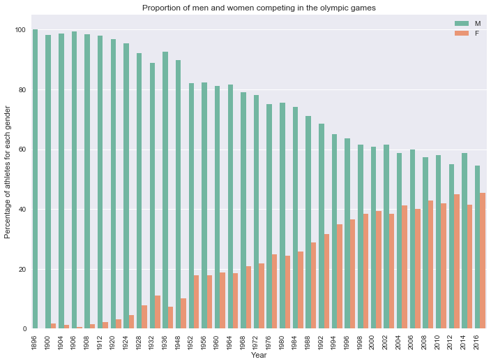

```python
a4_dims = (11.7, 8.27)
fig, ax = pyplot.subplots(figsize=a4_dims)

ax = sns.barplot(x="Year", y="Name", hue="Sex", data=percentages, palette="Set2")
ax.set_xticklabels(ax.get_xticklabels(), rotation=90, ha="right")
ax.set_title('Proportion of men and women competing in the olympic games')
ax.set_ylabel('Percentage of athletes for each gender')
ax.legend(loc="upper right")
plt.show()
```

*Insights:*

- Good news! The ratio of male to female competitors is slowly becoming more balanced - could 2020 be the year that we have an equal number of female competitors and male competitors?

### The changing profile of the Olympic athlete (part 2)

The visualisation below shows how the distribution of men and women's ages have changed since 1896, split by Sex and Summer/Winter Olympics

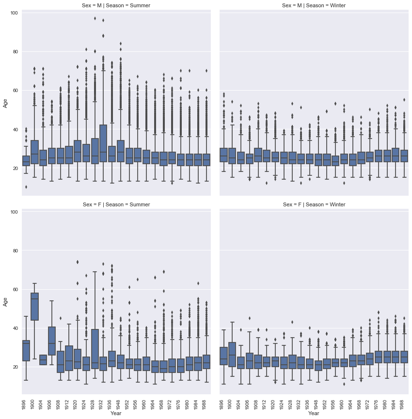

```python
sns.set(rc={'figure.figsize':(20,20)})

g = sns.FacetGrid(clean_data, col="Season",  row="Sex", size=6)
g = g.map(sns.boxplot, "Year", 'Age')
g.set_xticklabels(ax.get_xticklabels(), rotation=90, ha="right")


show()
```

*Insights:*

- some 'athletes' in the 20th century were > 80 years when they competed! Worth a quick look back at the data to see what they competed in.
- As could be expected, variance is greatly reduced in the modern athletes age (with the median Age being in the early 20's. Interestingly the median age in the winter olympics seems to be higher.
- Higher variance in the Summer Olympics - I would hypothesise this is down to the wider variety of sports on offer at the Summer Olympics.

# Analysis of some interesting countries

```python
#create a table of year,countryname & sex to be merged into a count of each later.
mini_country_table = clean_data[clean_data['Season'] == 'Summer'].loc[:, ['Year','AthleteCountry', 'Name', 'Sex']].drop_duplicates()
mini_country_table.head()
```

|  | Year | AthleteCountry | Name | Sex |
| --- | --- | --- | --- | --- |
| 0 | 1992 | China | A Dijiang | M |
| 1 | 1992 | China | Bai Chongguang | M |
| 2 | 1992 | China | Bai Mei | F |
| 3 | 1992 | China | Bi Zhong | M |
| 4 | 1992 | China | Cai Yanshu | M |

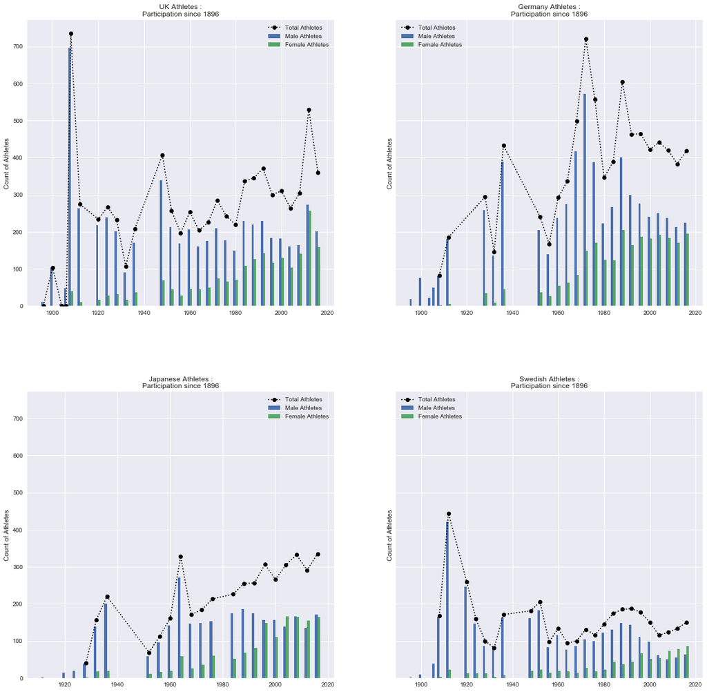

```python
# Create a pivot table to count gender wise representation of each team in each year
CountAthletesByCountry = pd.pivot_table(mini_country_table,
                                        index = ['Year', 'AthleteCountry'],
                                        columns = 'Sex',
                                        aggfunc = 'count').reset_index()

# rename columns as per column names in the 0th level
CountAthletesByCountry.columns = CountAthletesByCountry.columns.get_level_values(0)

# rename the columns appropriately
CountAthletesByCountry.columns = ['Year', 'AthleteCountry', 'Female_Athletes', 'Male_Athletes']

# get total athletes per team-year
CountAthletesByCountry['Total_Athletes'] = CountAthletesByCountry['Female_Athletes'] + \
CountAthletesByCountry['Male_Athletes']

uk_athletes = CountAthletesByCountry[CountAthletesByCountry['AthleteCountry'] == "United Kingdom"]
uk_athletes.fillna(0, inplace = True)
uk_athletes.set_index('Year', inplace = True)

swedish_athletes = CountAthletesByCountry[CountAthletesByCountry['AthleteCountry'] == "Sweden"]
swedish_athletes.set_index('Year', inplace = True)

japanese_athletes = CountAthletesByCountry[CountAthletesByCountry['AthleteCountry'] == "Japan"]
japanese_athletes.set_index('Year', inplace = True)

germany_athletes = CountAthletesByCountry[CountAthletesByCountry['AthleteCountry'] == "Germany"]
germany_athletes.set_index('Year', inplace = True)

# Plot the values of male, female and total athletes using bar charts and the line charts.
fig, ((ax1, ax2), (ax3, ax4)) = subplots(nrows = 2, ncols = 2, figsize = (20, 20), sharey = True)
fig.subplots_adjust(hspace = 0.3)

# Plot team Australia's contingent size
ax1.bar(uk_athletes.index.values, uk_athletes['Male_Athletes'], width = -1, align = 'edge', label = 'Male Athletes')
ax1.bar(uk_athletes.index.values, uk_athletes['Female_Athletes'], width = 1, align = 'edge', label = 'Female Athletes')
ax1.plot(uk_athletes.index.values, uk_athletes['Total_Athletes'], linestyle = ':', color = 'black', label = 'Total Athletes',
        marker = 'o')
ax1.legend(loc="upper right")
ax1.set_title('UK Athletes :\nParticipation since 1896')
ax1.set_ylabel('Count of Athletes')

# Plot German athlete participation
ax2.bar(germany_athletes.index.values, germany_athletes['Male_Athletes'], width = -1, align = 'edge', label = 'Male Athletes')
ax2.bar(germany_athletes.index.values, germany_athletes['Female_Athletes'], width = 1, align = 'edge', label = 'Female Athletes')
ax2.plot(germany_athletes.index.values, germany_athletes['Total_Athletes'], linestyle = ':', color = 'black', label = 'Total Athletes',
        marker = 'o')
ax2.set_title('Germany Athletes :\nParticipation since 1896')
ax2.legend(loc="upper left")

ax2.set_ylabel('Count of Athletes')

# Plot Japan's contingent size
ax3.bar(japanese_athletes.index.values, japanese_athletes['Male_Athletes'], width = -1, align = 'edge', label = 'Male Athletes')
ax3.bar(japanese_athletes.index.values, japanese_athletes['Female_Athletes'], width = 1, align = 'edge', label = 'Female Athletes')
ax3.plot(japanese_athletes.index.values, japanese_athletes['Total_Athletes'], linestyle = ':', color = 'black', label = 'Total Athletes',
         marker = 'o')
ax3.set_title('Japanese Athletes :\nParticipation since 1896')
ax3.set_ylabel('Count of Athletes')
ax3.legend(loc="upper right")


# Plot team Swedens's contingent size
ax4.bar(swedish_athletes.index.values, swedish_athletes['Male_Athletes'], width = -1, align = 'edge', label = 'Male Athletes')
ax4.bar(swedish_athletes.index.values, swedish_athletes['Female_Athletes'], width = 1, align = 'edge', label = 'Female Athletes')
ax4.plot(swedish_athletes.index.values, swedish_athletes['Total_Athletes'], linestyle = ':', color = 'black', label = 'Total Athletes',
        marker = 'o')
ax4.set_title('Swedish Athletes :\nParticipation since 1896')
ax4.set_ylabel('Count of Athletes')
ax4.legend(loc="upper left")

show()
```

# Is there a correlation between Distance Travelled to the Games and performance and has that changed since 1980?

This is where we bring in the engineered feature 'DistanceTravelled' - the Vincenty distance between an athletes home capital and where the games took place. My hypothesis is that distance travelled has an impact of number of medals a Country receives (due to things physiological factors like jet-mind, blood flow etc), I also further hypothesise that the effect of this will be reduced in the modern era (I've chosen Pre/Post 1980).

To investigate these hypothesese, I've split the dataset (pre and post 1980) and calculate correlation between this distance and medals won. Obviously, whether a country has a high medal count is a multivariate problem and would require a more in-depth analysis in practice.

```python
# Get just the medalists
Subset_Medalists = clean_data['AnyMedals'] == 1

#Create a new dataset to be merged with the medal table dataset below
subset_distancetravelled = clean_data.loc[:, ['Year', 'AthleteCountry', 'DistanceTravelled']].drop_duplicates()

medal_tally = clean_data.groupby(['Year','AthleteCountry'])['TotalMedals'].agg('sum').reset_index()
medal_tally_byDistance = medal_tally.merge(subset_distancetravelled,
                                   left_on = ['Year', 'AthleteCountry'],
                                   right_on = ['Year', 'AthleteCountry'],
                                   how = 'left')

#create two datasets to compare correlations
Pre_1980_MedalTallyByDistance = medal_tally_byDistance[medal_tally_byDistance['Year']<=1980]
Post_1980_MedalTallyByDistance = medal_tally_byDistance[medal_tally_byDistance['Year']>1980]

medal_tally_byDistance.head()
```

|  | Year | AthleteCountry | TotalMedals | DistanceTravelled |
| --- | --- | --- | --- | --- |
| 0 | 1896 | Australia | 3.0 | 15201.660597 |
| 1 | 1896 | Austria | 5.0 | 1282.025503 |
| 2 | 1896 | Denmark | 6.0 | 2135.520896 |
| 3 | 1896 | France | 11.0 | 2100.783748 |
| 4 | 1896 | Germany | 32.0 | 1802.949137 |

### Pre-1980: impact of distance travelled on country performance

```
Text(18557.7,446,'Correlation = -0.146533766948')
```

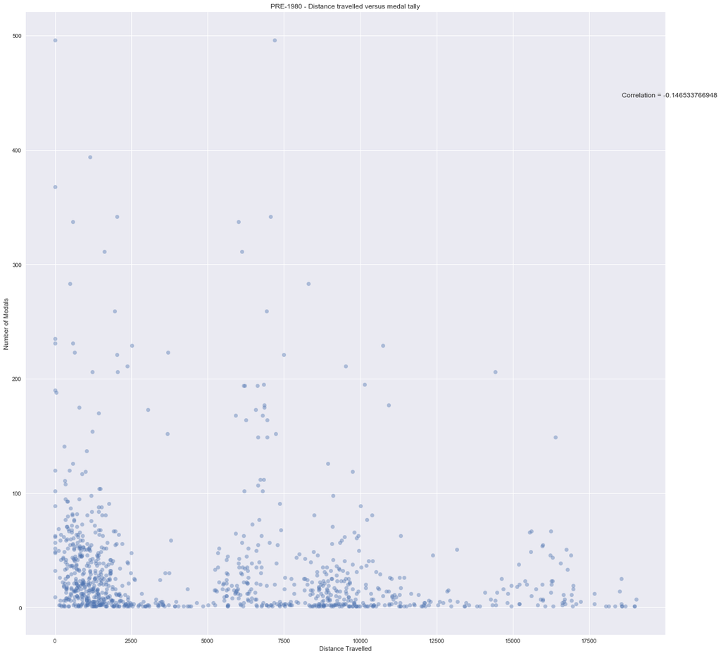

```python
selected_rows = Pre_1980_MedalTallyByDistance['TotalMedals'] > 0

correlation = Pre_1980_MedalTallyByDistance.loc[selected_rows, ['DistanceTravelled', 'TotalMedals']].corr()['TotalMedals'][0]

plot(Pre_1980_MedalTallyByDistance.loc[selected_rows, 'DistanceTravelled'],
     Pre_1980_MedalTallyByDistance.loc[selected_rows, 'TotalMedals'] ,
     linestyle = 'none',
     marker = 'o',
     alpha = 0.4)
xlabel('Distance Travelled')

ylabel('Number of Medals')
title('PRE-1980 - Distance travelled versus medal tally')
text(np.nanpercentile(Pre_1980_MedalTallyByDistance['DistanceTravelled'], 99.6),
     max(Pre_1980_MedalTallyByDistance['TotalMedals']) - 50,
     "Correlation = " + str(correlation))
```

### Post-1980: impact of distance travelled on country performance

```
Text(18738.3,316,'Correlation = -0.0614926627557')
```

[figure not shown]

```python
selected_rows = Post_1980_MedalTallyByDistance['TotalMedals'] > 0

correlation = Post_1980_MedalTallyByDistance.loc[selected_rows, ['DistanceTravelled', 'TotalMedals']].corr()['TotalMedals'][0]

plot(Post_1980_MedalTallyByDistance.loc[selected_rows, 'DistanceTravelled'],
     Post_1980_MedalTallyByDistance.loc[selected_rows, 'TotalMedals'] ,
     linestyle = 'none',
     marker = 'o',
    alpha = 0.4)
xlabel('Distance Travelled')

ylabel('Number of Medals')
title('POST-1960 - Distance travelled versus medal tally')
text(np.nanpercentile(Post_1980_MedalTallyByDistance['DistanceTravelled'], 99.6),
     max(Post_1980_MedalTallyByDistance['TotalMedals']) - 50,
     "Correlation = " + str(correlation))
```

# Conclusions and further research options

This was an enjoyable task! I focused my efforts on data engineering and manfuactures some novel features. The following insights were of most interest to me:

- good to see gender balance finally becoming a reality (after over 120 years of competition!
- following high variance in the early years, most athletes are in there early 20's (slightly higher median age for the Winter Olympics).
- of all interesting countries selected for this study (UK, Germany, Sweden & Japan), Germany send the most athletes (on average each year),

Given more time, I would like to:

- add more summary statistics,
- explore covariance,
- build predictive models (i.e. predicting the medals table at the next Games),
- conduct a clustering analysis to so what separates the best athletes from OK athletes.

# ...any finally - what about the Jamaican bobsleigh team?

It wouldn't be a proper Olympic analysis without a look at how the Jamaican bobsleigh team have done over the years

```python
#df[(df['coverage']  > 50) & (df['reports'] < 4)]
jamaicans = clean_data[(clean_data['AthleteCountry'] == 'Jamaica') & (clean_data['Sport'] == 'Bobsleigh') ]
jamaican_grouped = jamaicans.groupby(['Year','City'])['TotalMedals'].agg('sum').reset_index()
jamaican_grouped
```

|  | Year | City | TotalMedals |
| --- | --- | --- | --- |
| 0 | 1988 | Calgary | 0 |
| 1 | 1992 | Albertville | 0 |
| 2 | 1994 | Lillehammer | 0 |
| 3 | 1998 | Nagano | 0 |
| 4 | 2002 | Salt Lake City | 0 |
| 5 | 2014 | Sochi | 0 |

```python
new_data = {'Year': [2018, 2022], 'City': ["Pyeongchang", "Beijing"], 'TotalMedals': [0, NaN]}
future_results = pd.DataFrame(new_data)
combined = pd.concat([jamaican_grouped, future_results])
combined
```

|  | City | TotalMedals | Year |
| --- | --- | --- | --- |
| 0 | Calgary | 0.0 | 1988 |
| 1 | Albertville | 0.0 | 1992 |
| 2 | Lillehammer | 0.0 | 1994 |
| 3 | Nagano | 0.0 | 1998 |
| 4 | Salt Lake City | 0.0 | 2002 |
| 5 | Sochi | 0.0 | 2014 |
| 0 | Pyeongchang | 0.0 | 2018 |
| 1 | Beijing | NaN | 2022 |

[output not shown]

[figure not shown]

```python
plt.bar(combined['Year'],combined['TotalMedals'] )
fig.suptitle('test title', fontsize=20)
plt.xlabel('Olympic Year', fontsize=18)
plt.ylabel('Number of medals won', fontsize=16)
plt.ylim((0,10))
plt.xticks(combined['Year'])
```

## Unfortunately, no medals yet for the Jamaican's in the Bobsleigh, maybe 2022 is their year?

[figure not shown]

Hope you enjoyed reading!

# ------------- > Back to Top < -------------